# Lab-2

## Practical Lab 2: Multivariate Linear Regression, Non-Parametric Models and Cross-Validation

### PART 1

### Loading dataset and framing problem

```python
import numpy as np
import pandas as pd
import matplotlib.pyplot as plt
import seaborn as sns
from sklearn import datasets
from sklearn.model_selection import train_test_split
from sklearn.preprocessing import PolynomialFeatures
from sklearn.linear_model import LinearRegression
from sklearn.metrics import r2_score, mean_absolute_error, mean_absolute_percentage_error

diabetes = datasets.load_diabetes(as_frame=True)
df = diabetes.frame
df.head()
```

|  | age | sex | bmi | bp | s1 | s2 | s3 | s4 | s5 | s6 | target |
| --- | --- | --- | --- | --- | --- | --- | --- | --- | --- | --- | --- |
| 0 | 0.038076 | 0.050680 | 0.061696 | 0.021872 | -0.044223 | -0.034821 | -0.043401 | -0.002592 | 0.019907 | -0.017646 | 151.0 |
| 1 | -0.001882 | -0.044642 | -0.051474 | -0.026328 | -0.008449 | -0.019163 | 0.074412 | -0.039493 | -0.068332 | -0.092204 | 75.0 |
| 2 | 0.085299 | 0.050680 | 0.044451 | -0.005670 | -0.045599 | -0.034194 | -0.032356 | -0.002592 | 0.002861 | -0.025930 | 141.0 |
| 3 | -0.089063 | -0.044642 | -0.011595 | -0.036656 | 0.012191 | 0.024991 | -0.036038 | 0.034309 | 0.022688 | -0.009362 | 206.0 |
| 4 | 0.005383 | -0.044642 | -0.036385 | 0.021872 | 0.003935 | 0.015596 | 0.008142 | -0.002592 | -0.031988 | -0.046641 | 135.0 |

## Framing the problem

This lab is focused on building a model that will predict the development of diabetes one year from baseline. We are going to create various models, support this, and calculate their performance through metrics such as R-squared, Mean Absolute Error, and Mean Absolute Percentage Error. The prediction will be used to identify patients who are at risk.

## EDA (Exploratory Data Analysis)

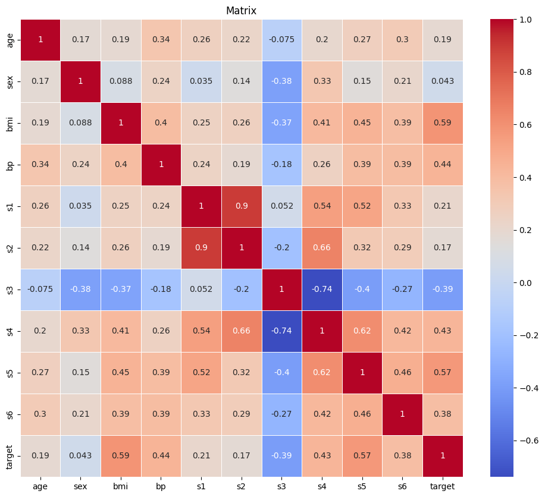

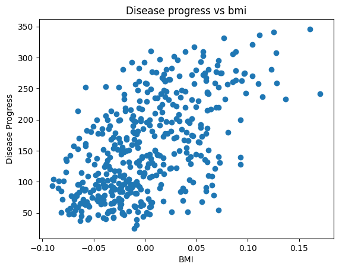

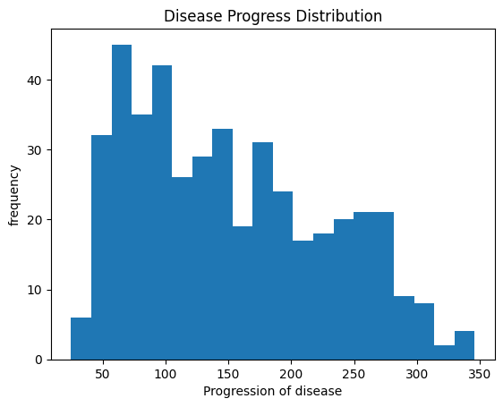

```python
df.describe()

matrix_cor = df.corr()
plt.figure(figsize=(12, 10))
sns.heatmap(matrix_cor, annot=True, cmap='coolwarm', linewidths=0.5)
plt.title("Matrix")
plt.show()

plt.scatter(df['bmi'], df['target'])
plt.xlabel('BMI')
plt.ylabel('Disease Progress')
plt.title('Disease progress vs bmi')
plt.show()

plt.hist(df['target'], bins=20)
plt.title('Disease Progress Distribution')
plt.xlabel('Progression of disease')
plt.ylabel('frequency')
plt.show()
```

## Clean the data if needed, and explain your reasoning for your reader

There are no omissions or otherwise patently incorrect data in this dataset. There are no other cleaning steps necessary at this stage.

## Split the dataset to a train (75%) and validation set (10%), and test set (15%).

```python
train_x, temp_x, train_y, temp_y = train_test_split(df.drop(columns=['target']), df['target'], test_size=0.25, random_state=42)
val_X, test_X, val_y, test_y = train_test_split(temp_x, temp_y, test_size=0.6, random_state=42)
```

# PART2

### Models: a univariate polynomial regression on the BMI feature versus the "disease progression one year after baseline" - from degree 0 to 5 (6 models)

```python
train_x_bmi = train_x[['bmi']]
val_x_bmi = val_X[['bmi']]
test_x_bmi = test_X[['bmi']]

scores_train = []
scores_val = []
mae_train = []
mae_val = []
mape_train = []
mape_val = []

degrees = [0, 1, 2, 3, 4, 5]

for degree in degrees:
    poly = PolynomialFeatures(degree)
    X_train_poly = poly.fit_transform(train_x_bmi)
    X_val_poly = poly.transform(val_x_bmi)

    model = LinearRegression()
    model.fit(X_train_poly, train_y)

    pred_train_y = model.predict(X_train_poly)
    pred_val_y = model.predict(X_val_poly)

    r2_train = r2_score(train_y, pred_train_y)
    r2_val = r2_score(val_y, pred_val_y)
    value_mae_train = mean_absolute_error(train_y, pred_train_y)
    value_mae_val = mean_absolute_error(val_y, pred_val_y)
    value_mape_train = mean_absolute_percentage_error(train_y, pred_train_y)
    value_mape_val = mean_absolute_percentage_error(val_y, pred_val_y)

    scores_train.append(r2_train)
    scores_val.append(r2_val)
    mae_train.append(value_mae_train)
    mae_val.append(value_mae_val)
    mape_train.append(value_mape_train)
    mape_val.append(value_mape_val)

    print(f"Polynomial Degree {degree}:")
    print(f"Train R-squared: {r2_train}, Validation R-squared: {r2_val}")
    print(f"Train MAE: {value_mae_train}, Validation MAE: {value_mae_val}")
    print(f"Train MAPE: {value_mape_train}, Validation MAPE: {value_mape_val}")

results = pd.DataFrame({
    'Degree': degrees,
    'Train R2': scores_train,
    'Validation R2': scores_val,
    'Train MAE': mae_train,
    'Validation MAE': mae_val,
    'Train MAPE': mape_train,
    'Validation MAPE': mape_val
})
```

```
Polynomial Degree 0:
Train R-squared: 0.0, Validation R-squared: -0.10695658646940309
Train MAE: 66.20164109491516, Validation MAE: 66.05705850041198
Train MAPE: 0.6282666949166479, Validation MAPE: 0.7126388036481317
Polynomial Degree 1:
Train R-squared: 0.34967185121455036, Validation R-squared: 0.33126358919280885
Train MAE: 52.28773945157054, Validation MAE: 47.20847217273694
Train MAPE: 0.483628861563456, Validation MAPE: 0.47060009012494425
Polynomial Degree 2:
Train R-squared: 0.3507638912961787, Validation R-squared: 0.33163059113292626
Train MAE: 52.20731378788719, Validation MAE: 47.21369996491131
Train MAPE: 0.48298534457931425, Validation MAPE: 0.4723966741140025
Polynomial Degree 3:
Train R-squared: 0.3507739717064434, Validation R-squared: 0.3316375420464187
Train MAE: 52.19896750707647, Validation MAE: 47.185413892618996
Train MAPE: 0.4828074375642864, Validation MAPE: 0.47222673165700857
Polynomial Degree 4:
Train R-squared: 0.3530137354946927, Validation R-squared: 0.3407583945439766
Train MAE: 52.09265315815546, Validation MAE: 46.09011849968036
Train MAPE: 0.48053266051672733, Validation MAPE: 0.4605032994688543
Polynomial Degree 5:
Train R-squared: 0.3541002641813574, Validation R-squared: 0.34988122550535306
Train MAE: 52.05919085943837, Validation MAE: 45.4621212276793
Train MAPE: 0.48004021759374493, Validation MAPE: 0.4517527518255973
```

## Summarizing the train validation results.

```python
# Summarizing the results in a table
results = pd.DataFrame({
    'Degree': degrees,
    'R2 train': scores_train,
    'R2 validation': scores_val,
    'MAE Train': mae_train,
    'MAE Validation': mae_val,
    'MAPE Train': mape_train,
    'MAPE Validation': mape_val
})

print(results)
```

```
   Degree  R2 train  R2 validation  MAE Train  MAE Validation  MAPE Train  \
0       0  0.000000      -0.106957  66.201641       66.057059    0.628267
1       1  0.349672       0.331264  52.287739       47.208472    0.483629
2       2  0.350764       0.331631  52.207314       47.213700    0.482985
3       3  0.350774       0.331638  52.198968       47.185414    0.482807
4       4  0.353014       0.340758  52.092653       46.090118    0.480533
5       5  0.354100       0.349881  52.059191       45.462121    0.480040

   MAPE Validation
0         0.712639
1         0.470600
2         0.472397
3         0.472227
4         0.460503
5         0.451753
```

## Identify the best model based on the table above

```python
idx_best_model = results['R2 validation'].idxmax()
degree_best_model = results.loc[idx_best_model, 'Degree']
print(f"The best model is polynomial degree {degree_best_model}")
```

```
The best model is polynomial degree 5
```

## Run the chosen model on the test set and provide results

```python
poly = PolynomialFeatures(degree=degree_best_model)
poltrain_y_x = poly.fit_transform(train_x_bmi)
poly_test_x = poly.transform(test_x_bmi)

model = LinearRegression()
model.fit(poltrain_y_x, train_y)
pred_test_y = model.predict(poly_test_x)

test_r2 = r2_score(test_y, pred_test_y)
test_mae = mean_absolute_error(test_y, pred_test_y)
test_mape = mean_absolute_percentage_error(test_y, pred_test_y)

print(f"Test R-squared: {test_r2}")
print(f"Test MAE: {test_mae}")
print(f"Test MAPE: {test_mape}")
```

```
Test R-squared: 0.26669658449530775
Test MAE: 51.75025709277397
Test MAPE: 0.4302671323305443
```

## Plot a graph of the train, validation and test data points, and the fit of the chosen model over each of them

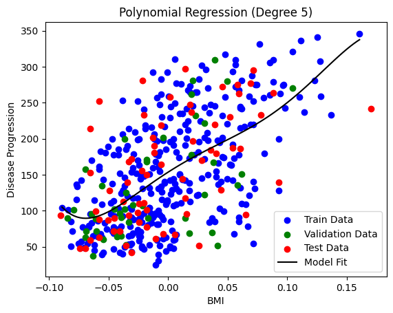

```python
plt.scatter(train_x_bmi, train_y, label='Train Data', color='blue')
plt.scatter(val_x_bmi, val_y, label='Validation Data', color='green')
plt.scatter(test_x_bmi, test_y, label='Test Data', color='red')

range_x = np.linspace(min(train_x_bmi['bmi']), max(train_x_bmi['bmi']), 100).reshape(-1, 1)
poly_range_x = poly.transform(range_x)
pred_range_y = model.predict(poly_range_x)
plt.plot(range_x, pred_range_y, color='black', label='Model Fit')

plt.legend()
plt.xlabel('BMI')
plt.ylabel('Disease Progression')
plt.title(f'Polynomial Regression (Degree {degree_best_model})')
plt.show()
```

```python
coeffs = model.coef_
intercept = model.intercept_
print(f"Equation: y = {intercept:.2f} + {coeffs[1]:.2f}*BMI + {coeffs[2]:.2f}*BMI^2")
```

```
Equation: y = 153.65 + 1059.89*BMI + -3824.15*BMI^2
```

## Calculate the expected diabetes progression for a BMI value of your choice using `model.perdict()` for that value

```python
value_bmi = np.array([[0.04]])  # Example BMI value
poly_bmi = poly.transform(value_bmi)
progression_predicted = model.predict(poly_bmi)
print(f"Predicted disease progression for BMI {value_bmi[0][0]}: {progression_predicted[0]}")
```

```
Predicted disease progression for BMI 0.04: 190.4812787808646
```

### Number of Parameters

```python
params_trainable_num = len(poly.get_feature_names_out())
print(f"Number of trainable parameters: {params_trainable_num}")
```

```
Number of trainable parameters: 6
```

# PART3

## 1.Two polynomial models (degrees >1, of your choice)

```python
train_x_multi = train_x
multi_x_val = val_X
multi_x_test = test_X

poly2 = PolynomialFeatures(degree=2)
poly2_x_train = poly2.fit_transform(train_x_multi)
poly2_x_val = poly2.transform(multi_x_val)

model_poly2 = LinearRegression()
model_poly2.fit(poly2_x_train, train_y)

train_y_pred_poly2 = model_poly2.predict(poly2_x_train)
y_val_pred_poly2 = model_poly2.predict(poly2_x_val)

poly2_train_r2 = r2_score(train_y, train_y_pred_poly2)
poly2_val_r2 = r2_score(val_y, y_val_pred_poly2)
poly2_train_mae = mean_absolute_error(train_y, train_y_pred_poly2)
poly2_val_mae = mean_absolute_error(val_y, y_val_pred_poly2)
poly2_train_mape = mean_absolute_percentage_error(train_y, train_y_pred_poly2)
poly2_val_mape = mean_absolute_percentage_error(val_y, y_val_pred_poly2)
print(f"Degree 2 Polynomial Model - Train R2: {poly2_train_r2}, Val R2: {poly2_val_r2}")
print(f"Train MAE: {poly2_train_mae}, Val MAE: {poly2_val_mae}")
print(f"Train MAPE: {poly2_train_mape}, Val MAPE: {poly2_val_mape}")

poly3 = PolynomialFeatures(degree=3)
X_train_poly3 = poly3.fit_transform(train_x_multi)
X_val_poly3 = poly3.transform(multi_x_val)

model_poly3 = LinearRegression()
model_poly3.fit(X_train_poly3, train_y)

train_y_pred_poly3 = model_poly3.predict(X_train_poly3)
y_val_pred_poly3 = model_poly3.predict(X_val_poly3)

train_r2_poly3 = r2_score(train_y, train_y_pred_poly3)
val_r2_poly3 = r2_score(val_y, y_val_pred_poly3)
train_mae_poly3 = mean_absolute_error(train_y, train_y_pred_poly3)
val_mae_poly3 = mean_absolute_error(val_y, y_val_pred_poly3)
train_mape_poly3 = mean_absolute_percentage_error(train_y, train_y_pred_poly3)
val_mape_poly3 = mean_absolute_percentage_error(val_y, y_val_pred_poly3)

print(f"Degree 3 Polynomial Model - Train R2: {train_r2_poly3}, Val R2: {val_r2_poly3}")
print(f"Train MAE: {train_mae_poly3}, Val MAE: {val_mae_poly3}")
print(f"Train MAPE: {train_mape_poly3}, Val MAPE: {val_mape_poly3}")
```

```
Degree 2 Polynomial Model - Train R2: -1.2307233493103689, Val R2: -1.6776598131668905
Train MAE: 90.77341389728096, Val MAE: 90.06818181818181
Train MAPE: 0.7812864146270092, Val MAPE: 0.9549328511984373
Degree 3 Polynomial Model - Train R2: 0.6219866744585079, Val R2: -45.38353372351955
Train MAE: 37.98187311178248, Val MAE: 243.5681818181818
Train MAPE: 0.32131199769548624, Val MAPE: 2.1655582844981693
```

## 2 Two decision trees (e.g. consider changing the `max_depth` hyperparameter)

```python
from sklearn.tree import DecisionTreeRegressor

tree1 = DecisionTreeRegressor(max_depth=3)
tree1.fit(train_x_multi, train_y)

train_y_pred_tree1 = tree1.predict(train_x_multi)
y_val_pred_tree1 = tree1.predict(multi_x_val)

train_r2_tree1 = r2_score(train_y, train_y_pred_tree1)
val_r2_tree1 = r2_score(val_y, y_val_pred_tree1)
train_mae_tree1 = mean_absolute_error(train_y, train_y_pred_tree1)
val_mae_tree1 = mean_absolute_error(val_y, y_val_pred_tree1)
train_mape_tree1 = mean_absolute_percentage_error(train_y, train_y_pred_tree1)
val_mape_tree1 = mean_absolute_percentage_error(val_y, y_val_pred_tree1)

print(f"Decision Tree (max_depth=3) - Train R2: {train_r2_tree1}, Val R2: {val_r2_tree1}")
print(f"Train MAE: {train_mae_tree1}, Val MAE: {val_mae_tree1}")
print(f"Train MAPE: {train_mape_tree1}, Val MAPE: {val_mape_tree1}")

tree2 = DecisionTreeRegressor(max_depth=5)
tree2.fit(train_x_multi, train_y)

train_y_pred_tree2 = tree2.predict(train_x_multi)
y_val_pred_tree2 = tree2.predict(multi_x_val)

train_r2_tree2 = r2_score(train_y, train_y_pred_tree2)
val_r2_tree2 = r2_score(val_y, y_val_pred_tree2)
train_mae_tree2 = mean_absolute_error(train_y, train_y_pred_tree2)
val_mae_tree2 = mean_absolute_error(val_y, y_val_pred_tree2)
train_mape_tree2 = mean_absolute_percentage_error(train_y, train_y_pred_tree2)
val_mape_tree2 = mean_absolute_percentage_error(val_y, y_val_pred_tree2)

print(f"Decision Tree (max_depth=5) - Train R2: {train_r2_tree2}, Val R2: {val_r2_tree2}")
print(f"Train MAE: {train_mae_tree2}, Val MAE: {val_mae_tree2}")
print(f"Train MAPE: {train_mape_tree2}, Val MAPE: {val_mape_tree2}")
```

```
Decision Tree (max_depth=3) - Train R2: 0.5095025444869563, Val R2: 0.19830582865255408
Train MAE: 44.25985495355638, Val MAE: 48.12624849350856
Train MAPE: 0.3886659196381194, Val MAPE: 0.4767289713964773
Decision Tree (max_depth=5) - Train R2: 0.6866927308225991, Val R2: 0.11391847129669808
Train MAE: 33.5270284885342, Val MAE: 50.07730137987713
Train MAPE: 0.29973624689610723, Val MAPE: 0.4790040030122181
```

## 3 Two kNNs

```python
from sklearn.neighbors import KNeighborsRegressor

knn1 = KNeighborsRegressor(n_neighbors=5)
knn1.fit(train_x_multi, train_y)

train_y_pred_knn1 = knn1.predict(train_x_multi)
y_val_pred_knn1 = knn1.predict(multi_x_val)

train_r2_knn1 = r2_score(train_y, train_y_pred_knn1)
val_r2_knn1 = r2_score(val_y, y_val_pred_knn1)
train_mae_knn1 = mean_absolute_error(train_y, train_y_pred_knn1)
val_mae_knn1 = mean_absolute_error(val_y, y_val_pred_knn1)
train_mape_knn1 = mean_absolute_percentage_error(train_y, train_y_pred_knn1)
val_mape_knn1 = mean_absolute_percentage_error(val_y, y_val_pred_knn1)

print(f"kNN (k=5) - Train R2: {train_r2_knn1}, Val R2: {val_r2_knn1}")
print(f"Train MAE: {train_mae_knn1}, Val MAE: {val_mae_knn1}")
print(f"Train MAPE: {train_mape_knn1}, Val MAPE: {val_mape_knn1}")

knn2 = KNeighborsRegressor(n_neighbors=10)
knn2.fit(train_x_multi, train_y)

train_y_pred_knn2 = knn2.predict(train_x_multi)
y_val_pred_knn2 = knn2.predict(multi_x_val)

train_r2_knn2 = r2_score(train_y, train_y_pred_knn2)
val_r2_knn2 = r2_score(val_y, y_val_pred_knn2)
train_mae_knn2 = mean_absolute_error(train_y, train_y_pred_knn2)
val_mae_knn2 = mean_absolute_error(val_y, y_val_pred_knn2)
train_mape_knn2 = mean_absolute_percentage_error(train_y, train_y_pred_knn2)
val_mape_knn2 = mean_absolute_percentage_error(val_y, y_val_pred_knn2)

# Print results for kNN 2 (k=10)
print(f"kNN (k=10) - Train R2: {train_r2_knn2}, Val R2: {val_r2_knn2}")
print(f"Train MAE: {train_mae_knn2}, Val MAE: {val_mae_knn2}")
print(f"Train MAPE: {train_mape_knn2}, Val MAPE: {val_mape_knn2}")
```

[output not shown]

[output not shown]